# Logistische Regression

Die Logistische Regression ist ein Regressionsverfahren, das dann Anwendung findet, wenn die abhängige Variable y nur zwei Zustände annehmen kann, also z.B. *0* oder *1*, *True* oder *False* etc. Ein wichtiges Anwendungsgebiet ist Predictive Maintenance. Obwohl es es sich um ein Regressionsverfahren handelt, wird die Logistische Regression auch als Klassifikationsmodell verwendet, indem ein Schwellenwert (Threshold, Cut-Off) definiert wird. Wird dieser überschritten, so sagt das Modell *1* oder *True* voraus, ansonsten *0* oder *False*.

## Beispiel 1

Wir erstellen einen einfachen Beispieldatensatz mit Daten über die Anzahl der Schuljahre und ob die befragten Personen Führungskraft sind oder nicht:

```python
import pandas as pd

df = pd.DataFrame({"Schuljahre":[8,9,13,13,8,10,10,9,10,9,11,8,15,13,10],
                  "IstFuehrungskraft": [0,0,1,1,0,1,0,0,0,0,1,0,1,0,0]})


df
```

|  | Schuljahre | IstFuehrungskraft |
| --- | --- | --- |
| 0 | 8 | 0 |
| 1 | 9 | 0 |
| 2 | 13 | 1 |
| 3 | 13 | 1 |
| 4 | 8 | 0 |
| 5 | 10 | 1 |
| 6 | 10 | 0 |
| 7 | 9 | 0 |
| 8 | 10 | 0 |
| 9 | 9 | 0 |
| 10 | 11 | 1 |
| 11 | 8 | 0 |
| 12 | 15 | 1 |
| 13 | 13 | 0 |
| 14 | 10 | 0 |

Wir erstellen ein *glm*-Objekt (Generalized Linear Model). Dass es sich um eine Logistische Regression handeln soll, teilen wir der Funktion durch die Angabe *family=sm.families.Binomial* mit.

```python
import statsmodels.formula.api as smf
import statsmodels.api as sm

model = smf.glm("IstFuehrungskraft~Schuljahre", data=df, family=sm.families.Binomial()).fit()
model.params
```

```
Intercept    -10.695596
Schuljahre     0.933998
dtype: float64
```

$\frac{ 1 }{ 1+e^{10.695596 - 0.933998x} } = 0,92$

Oder wir verwenden die Funktion *predict*:

```python
model.predict(pd.DataFrame({"Schuljahre":[14]}))
```

```
0    0.915318
dtype: float64
```

Plotten wir noch die Funktion:

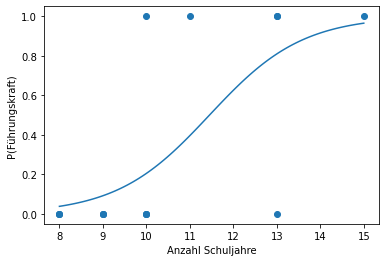

```python
%matplotlib inline
import matplotlib.pyplot as plt
import pandas as pd
import numpy as np

x = np.linspace(df.Schuljahre.min(), df.Schuljahre.max(), 100)
y = model.predict(pd.DataFrame({"Schuljahre":x}))

plt.scatter(df.Schuljahre, df.IstFuehrungskraft)
plt.plot(x,y)
plt.xlabel("Anzahl Schuljahre")
plt.ylabel("P(Führungskraft)")
plt.show()
```

Mit *seaborn* kann auch direkt ein Regressionsplot erstellt werden. Dazu setzt man die Option *logistic* auf *True*:

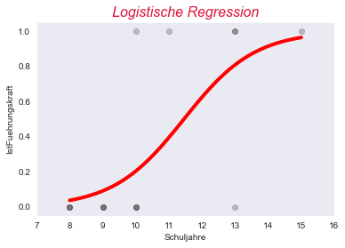

```python
import seaborn as sns
df = pd.DataFrame({"Schuljahre":[8,9,13,13,8,10,10,9,10,9,11,8,15,13,10],
                  "IstFuehrungskraft": [0,0,1,1,0,1,0,0,0,0,1,0,1,0,0]})
sns.set_style("dark")
plt.xlim(7, 16)
sns.regplot(x="Schuljahre", y="IstFuehrungskraft", data=df, logistic=True, ci=False,
           line_kws={"color":"red", "lw":4},
           scatter_kws={"alpha":0.2, "color":"k"})
plt.title("Logistische Regression", color="crimson", fontsize=16, fontstyle="italic")
#plt.ylabel(r"$p_{Führungskraft}$")
plt.show()
```

```python
model.predict(pd.DataFrame({"Schuljahre":[8]}))
```

```
0    0.038287
dtype: float64
```

## Beispiel 2:

Ein weiteres "ausgedachtes" Beispiel: Wahrscheinlichkeit, an Lungenkrebs zu erkranken in Abhängigkeit von der Anzahl Zigratten / Woche.

```python
import numpy as np
X = np.array([[0, "Nein"],
              [10, "Nein"],
              [60, "Ja"],
              [90, "Ja"]])
n = X.shape[0] # Anzahl Beobachtungen
print(X)
```

```
[['0' 'Nein']
 ['10' 'Nein']
 ['60' 'Ja']
 ['90' 'Ja']]
```

Wir erstellen das Modell. Hier verwenden wir die Klasse *LogisticRegression* aus dem Package *sklearn.linear_model*.

```python
from sklearn.linear_model import LogisticRegression
model = LogisticRegression().fit(X[:,0].reshape(-1,1), X[:,1])
print("Beta 0 = ", model.intercept_)
print("Beta 1 = ", model.coef_)
```

```
Beta 0 =  [7.74782809]
Beta 1 =  [[-0.21987113]]
```

```python
# Beispiele für Vorhersage: Wahrscheinlichkeiten für einige Beispieldaten.
zigaretten_tag = np.array([0, 3, 40, 50])
print(model.predict(zigaretten_tag.reshape(-1,1)))
```

```
['Nein' 'Nein' 'Ja' 'Ja']
```

Wir ploten die Sigmoid-Funktion.

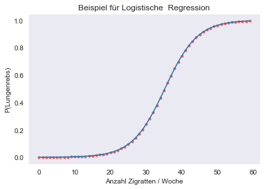

```python
%matplotlib inline
import matplotlib.pyplot as plt

x = np.arange(60)
y = model.predict_proba(x.reshape(-1,1))[:,0]

plt.scatter(x,y, c="red", s=10, alpha=.5)
plt.plot(x,y)
plt.title("Beispiel für Logistische  Regression")
plt.xlabel("Anzahl Zigratten / Woche")
plt.ylabel("P(Lungenrebs)")
plt.show()
```

## Beispiel 3: Shuttle (Challanger-Katastrophe)

Vorhersage, ob die verbaute Gummidichtung (O-Ring) bei der damals herrschenden Temperatur abdichtet. Wir laden den Datensatz *shuttle.csv* und führen eine Logistische Regression durch.

```python
import pandas as pd
import statsmodels.api as sms
import statsmodels.formula.api as sfm

url = "https://raw.githubusercontent.com/troescherw/datasets/master/shuttle.csv"
shuttle = pd.read_csv(url)

model = sfm.glm("r~temperature", data=shuttle, family=sms.families.Binomial()).fit()
model.summary()
```

Generalized Linear Model Regression Results

| Dep. Variable: | r | No. Observations: | 23 |
| --- | --- | --- | --- |
| Model: | GLM | Df Residuals: | 21 |
| Model Family: | Binomial | Df Model: | 1 |
| Link Function: | logit | Scale: | 1.0000 |
| Method: | IRLS | Log-Likelihood: | -10.158 |
| Date: | Fri, 31 Dec 2021 | Deviance: | 20.315 |
| Time: | 10:37:38 | Pearson chi2: | 23.2 |
| No. Iterations: | 5 |  |  |
| Covariance Type: | nonrobust |  |  |

|  | coef | std err | z | P>\|z\| | [0.025 | 0.975] |
| --- | --- | --- | --- | --- | --- | --- |
| Intercept | 15.0429 | 7.379 | 2.039 | 0.041 | 0.581 | 29.505 |
| temperature | -0.2322 | 0.108 | -2.145 | 0.032 | -0.444 | -0.020 |

Am Tag es Unglücks herrschten angeblich 31 Grad Fahrenheit (-0,6 Grad Celsius). Mit welcher Wahrscheinlichkeit war die Gummidichtung nicht funktionsfähig?

```python
model.predict(pd.DataFrame({"temperature":[31]}))
```

```
0    0.999609
dtype: float64
```

Erstellen wir noch einen Plot:

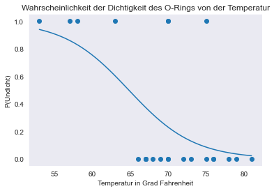

```python
import matplotlib.pyplot as plt
import numpy as np
x = np.linspace(shuttle.temperature.min(), shuttle.temperature.max(), 50)
y = model.predict(pd.DataFrame({"temperature": x}))

plt.scatter(shuttle.temperature, shuttle.r)
plt.plot(x,y)
plt.title("Wahrscheinlichkeit der Dichtigkeit des O-Rings von der Temperatur")
plt.xlabel("Temperatur in Grad Fahrenheit")
plt.ylabel("P(Undicht)")
plt.show()
```

## Beispiel 4: TITANIC

Überlebenswahrscheinlicheit auf der Titanic in Abhängigkeit von Geschlecht, Alter und Klasse.

```python
import pandas as pd

url = "https://raw.githubusercontent.com/troescherw/datasets/master/titanic.csv"
titanic = pd.read_csv(url)
titanic
```

|  | PassengerId | Survived | Pclass | Name | Sex | Age | SibSp | Parch | Ticket | Fare | Cabin | Embarked |
| --- | --- | --- | --- | --- | --- | --- | --- | --- | --- | --- | --- | --- |
| 0 | 1 | 0 | 3 | Braund, Mr. Owen Harris | male | 22.0 | 1 | 0 | A/5 21171 | 7.2500 | NaN | S |
| 1 | 2 | 1 | 1 | Cumings, Mrs. John Bradley (Florence Briggs Th... | female | 38.0 | 1 | 0 | PC 17599 | 71.2833 | C85 | C |
| 2 | 3 | 1 | 3 | Heikkinen, Miss. Laina | female | 26.0 | 0 | 0 | STON/O2. 3101282 | 7.9250 | NaN | S |
| 3 | 4 | 1 | 1 | Futrelle, Mrs. Jacques Heath (Lily May Peel) | female | 35.0 | 1 | 0 | 113803 | 53.1000 | C123 | S |
| 4 | 5 | 0 | 3 | Allen, Mr. William Henry | male | 35.0 | 0 | 0 | 373450 | 8.0500 | NaN | S |
| ... | ... | ... | ... | ... | ... | ... | ... | ... | ... | ... | ... | ... |
| 886 | 887 | 0 | 2 | Montvila, Rev. Juozas | male | 27.0 | 0 | 0 | 211536 | 13.0000 | NaN | S |
| 887 | 888 | 1 | 1 | Graham, Miss. Margaret Edith | female | 19.0 | 0 | 0 | 112053 | 30.0000 | B42 | S |
| 888 | 889 | 0 | 3 | Johnston, Miss. Catherine Helen "Carrie" | female | NaN | 1 | 2 | W./C. 6607 | 23.4500 | NaN | S |
| 889 | 890 | 1 | 1 | Behr, Mr. Karl Howell | male | 26.0 | 0 | 0 | 111369 | 30.0000 | C148 | C |
| 890 | 891 | 0 | 3 | Dooley, Mr. Patrick | male | 32.0 | 0 | 0 | 370376 | 7.7500 | NaN | Q |

891 rows × 12 columns

Wir wollen die Überlebenswahrscheinlichkeit (*Survived*) in Abhängigkeit von Alter (*Age*), Geschlecht (*Sex*) und der Klasse (*Pclass*) vorhersagen. Wir überprüfen zuersat, ob es NaNs im Datensatz gibt:

```python
titanic.isna().sum()
```

```
PassengerId      0
Survived         0
Pclass           0
Name             0
Sex              0
Age            177
SibSp            0
Parch            0
Ticket           0
Fare             0
Cabin          687
Embarked         2
dtype: int64
```

Bei *Age* gibt es 177 NaNs! Wir ersetzen diese durch den Mittelwert der Altersangaben.

```python
mean_age = titanic.Age.mean()
titanic.Age = titanic.Age.fillna(mean_age)
```

Nun teilen wir den Datensatz in einen Trainings- und Testdatensatz auf.70% verwenden wir für das Training, 30% für das Testen.

```python
from sklearn.model_selection import train_test_split
X = titanic[["Survived", "Age", "Sex", "Pclass"]]
y = titanic.Survived

X_train, X_test, y_train, y_test = train_test_split(X,y,shuffle=True, random_state=42, test_size=0.3)
```

Nun erstellen wir das Vorhersagemodell, erstellen anhand der Test-Daten eine Prognose und stellen das Ergebnis in einer Confusion-Matrix dar. Beim Geschlecht und bei der Klasse handelt es sich um kategoriale Variablen, daher setzen wir in der Formel diese Kategorien in Klammern hinter einem *C*.

```python
import statsmodels.api as sm
import statsmodels.formula.api as smf

model = smf.glm("Survived~Age+C(Sex)+C(Pclass)", data=X_train, family=sm.families.Binomial()).fit()
model.summary()
```

Generalized Linear Model Regression Results

| Dep. Variable: | Survived | No. Observations: | 623 |
| --- | --- | --- | --- |
| Model: | GLM | Df Residuals: | 618 |
| Model Family: | Binomial | Df Model: | 4 |
| Link Function: | logit | Scale: | 1.0000 |
| Method: | IRLS | Log-Likelihood: | -288.41 |
| Date: | Fri, 31 Dec 2021 | Deviance: | 576.83 |
| Time: | 10:37:38 | Pearson chi2: | 650. |
| No. Iterations: | 5 |  |  |
| Covariance Type: | nonrobust |  |  |

|  | coef | std err | z | P>\|z\| | [0.025 | 0.975] |
| --- | --- | --- | --- | --- | --- | --- |
| Intercept | 3.0911 | 0.420 | 7.358 | 0.000 | 2.268 | 3.914 |
| C(Sex)[T.male] | -2.5216 | 0.219 | -11.525 | 0.000 | -2.950 | -2.093 |
| C(Pclass)[T.2] | -0.7114 | 0.303 | -2.350 | 0.019 | -1.305 | -0.118 |
| C(Pclass)[T.3] | -2.0421 | 0.283 | -7.205 | 0.000 | -2.598 | -1.487 |
| Age | -0.0288 | 0.009 | -3.327 | 0.001 | -0.046 | -0.012 |

Die Vorhersage liefert uns die Wahrscheinlichkeiten. Wir setzen einen Cut-Off bei 0,5: Bei einer Überlebenswahrscheinlichkeit >0,5 setzen wir eine *1* (Survived), ansonsten eine *0*.

```python
from sklearn.metrics import classification_report

pred = model.predict(X_test)
pred_class =pd.Series([1 if x >0.5 else 0 for x in pred])

print(classification_report(y_test, pred_class))
```

```
              precision    recall  f1-score   support

           0       0.81      0.88      0.84       157
           1       0.80      0.70      0.75       111

    accuracy                           0.81       268
   macro avg       0.81      0.79      0.80       268
weighted avg       0.81      0.81      0.80       268
```

Wir erreichen also eine **Accuracy** von 81%.

Sagen wir die Überlebenswahrscheinlichkeit für einen männlichen Passagier, 20 Jahre in der 3. Klasse voraus:

```python
model.predict(pd.DataFrame({"Age": [20], "Sex":["male"], "Pclass" : 3}))
```

```
0    0.114215
dtype: float64
```

Erstellen wir noch einen Plot mit der Überlebenswahrscheinlichkeit in Abhängigkeit von Alter und Geschlecht der Passagiere der 1. Klasse:

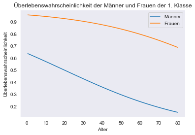

```python
import numpy as np
import matplotlib.pyplot as plt

x = np.linspace(titanic.Age.min(), titanic.Age.max(), 50)
y_male = model.predict(pd.DataFrame({"Sex":"male", "Age":x, "Pclass": 1}))
y_female = model.predict(pd.DataFrame({"Sex":"female", "Age":x, "Pclass": 1}))

plt.plot(x, y_male, label="Männer")
plt.plot(x, y_female, label="Frauen")
plt.legend()#
plt.xlabel("Alter")
plt.ylabel("Überlebenswahrscheinlichkeit")
plt.title("Überlebenswahrscheinlichkeit der Männer und Frauen der 1. Klasse")
plt.show()
```

## ROC-Kurve

Erstellen wir noch eine ROC-Kurve für unser Modell und geben die AUC aus.

```
AUC =  0.7908417972112239
```

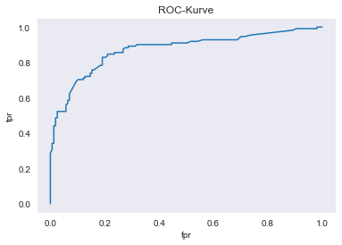

```python
from sklearn.metrics import roc_auc_score
from sklearn.metrics import roc_curve

fpr, tpr, thresholds = roc_curve(y_test, pred)

plt.plot(fpr, tpr)
plt.title("ROC-Kurve")
plt.xlabel("fpr")
plt.ylabel("tpr")
plt.plot()

print("AUC = ", roc_auc_score(y_test, pred_class))
```

## Beispiel 5: Vorhersage einer Herzkrankheit

Ein Beispiel aus der Medizin! Wir wollen anhand des Datensatzes *heartdisease.csv* mit den folgenden Features vorhersagen, ob eine Person an einer Herzkrankheit erkranken wird:

**Beschreibung der Features:**

| Feature | Bedeutung |
| --- | --- |
| **age** | age in years |
| **sex** | sex (1 = male; 0 = female) |
| **cp** | chest pain type |
|  | Value 1 : typical angina |
|  | Value 2 : atypical angina |
|  | Value 3 : non-anginal pain |
|  | Value 4 : asymptomatic |
| **trestbps** | resting blood pressure (in mm Hg on admission to the hospital) |
| **chol** | serum cholestoral in mg/dl |
| **fbs** | (fasting blood sugar > 120 mg/dl) (1 = true; 0 = false) |
| **restecg** | resting electrocardiographic results |
|  | Value 0: normal |
|  | Value 1: having ST-T wave abnormality (T wave inversions and/or ST elevation or depression of > 0.05 mV) |
|  | Value 2: showing probable or definite left ventricular hypertrophy by Estes' criteria |
| **thalach** | maximum heart rate achieved |
| **exang** | exercise induced angina (1 = yes; 0 = no) |
| **oldpeak** | ST depression induced by exercise relative to rest |
| **slope** | the slope of the peak exercise ST segment |
|  | Value 1: upsloping |
|  | Value 2: flat |
|  | Value 3: downsloping |
| **ca** | number of major vessels (0-3) colored by flourosopy |
| **thal** | 3 = normal; 6 = fixed defect; 7 = reversable defect |
| **hd** | **diagnosis of heart disease** |

```python
import pandas as pd
url = "https://raw.githubusercontent.com/troescherw/datasets/master/heartdisease.csv"
headers = ["age","sex","cp","trestbps","chol","fbs","restecg","thalach","exang","oldpeak","slope","ca","thal","status"]
df = pd.read_csv(url, header=None)
df.columns=headers
df.status = ["krank" if x>=1 else "gesund" for x in df.status]
print(df.shape)
df.head()
```

```
(303, 14)
```

|  | age | sex | cp | trestbps | chol | fbs | restecg | thalach | exang | oldpeak | slope | ca | thal | status |
| --- | --- | --- | --- | --- | --- | --- | --- | --- | --- | --- | --- | --- | --- | --- |
| 0 | 63.0 | 1.0 | 1.0 | 145.0 | 233.0 | 1.0 | 2.0 | 150.0 | 0.0 | 2.3 | 3.0 | 0.0 | 6.0 | gesund |
| 1 | 67.0 | 1.0 | 4.0 | 160.0 | 286.0 | 0.0 | 2.0 | 108.0 | 1.0 | 1.5 | 2.0 | 3.0 | 3.0 | krank |
| 2 | 67.0 | 1.0 | 4.0 | 120.0 | 229.0 | 0.0 | 2.0 | 129.0 | 1.0 | 2.6 | 2.0 | 2.0 | 7.0 | krank |
| 3 | 37.0 | 1.0 | 3.0 | 130.0 | 250.0 | 0.0 | 0.0 | 187.0 | 0.0 | 3.5 | 3.0 | 0.0 | 3.0 | gesund |
| 4 | 41.0 | 0.0 | 2.0 | 130.0 | 204.0 | 0.0 | 2.0 | 172.0 | 0.0 | 1.4 | 1.0 | 0.0 | 3.0 | gesund |

```python
from sklearn.model_selection import train_test_split

X = df
y = df.status

# Trainings- und Testdaten
X_train, X_test, y_train, y_test = train_test_split(X,y,shuffle=True, random_state=0)
```

```python
import statsmodels.api as sm
import statsmodels.formula.api as smf
from sklearn.metrics import classification_report

# Modell erstellen
# cp, restecg und slope sind kategoriale Variablen
X = sm.add_constant(X)
model = smf.glm("C(status)~age+sex+C(cp)+trestbps+chol+fbs+C(restecg)+thalach+exang+oldpeak+C(slope)+ca+thal",
                data=X_train, family=sm.families.Binomial()).fit()

# Vorhersage mit Testdaten
pred = model.predict(X_test)
pred_class = ["gesund" if x >0.5 else "krank" for x in pred]

# Modellreport
print(classification_report(pred_class, y_test))
```

```
              precision    recall  f1-score   support

      gesund       0.85      0.76      0.80        45
       krank       0.69      0.81      0.75        31

    accuracy                           0.78        76
   macro avg       0.77      0.78      0.77        76
weighted avg       0.79      0.78      0.78        76
```

```python
model.summary()
```

Generalized Linear Model Regression Results

| Dep. Variable: | ['C(status)[gesund]', 'C(status)[krank]'] | No. Observations: | 227 |
| --- | --- | --- | --- |
| Model: | GLM | Df Residuals: | 204 |
| Model Family: | Binomial | Df Model: | 22 |
| Link Function: | logit | Scale: | 1.0000 |
| Method: | IRLS | Log-Likelihood: | -64.088 |
| Date: | Fri, 31 Dec 2021 | Deviance: | 128.18 |
| Time: | 10:37:39 | Pearson chi2: | 296. |
| No. Iterations: | 7 |  |  |
| Covariance Type: | nonrobust |  |  |

|  | coef | std err | z | P>\|z\| | [0.025 | 0.975] |
| --- | --- | --- | --- | --- | --- | --- |
| Intercept | 9.7744 | 3.921 | 2.493 | 0.013 | 2.089 | 17.460 |
| C(cp)[T.2.0] | -1.6902 | 1.002 | -1.687 | 0.092 | -3.654 | 0.274 |
| C(cp)[T.3.0] | -0.3421 | 0.888 | -0.385 | 0.700 | -2.082 | 1.398 |
| C(cp)[T.4.0] | -2.4047 | 0.894 | -2.688 | 0.007 | -4.158 | -0.652 |
| C(restecg)[T.1.0] | -0.4427 | 3.182 | -0.139 | 0.889 | -6.679 | 5.793 |
| C(restecg)[T.2.0] | -0.2381 | 0.485 | -0.491 | 0.623 | -1.188 | 0.712 |
| C(slope)[T.2.0] | -1.6602 | 0.561 | -2.960 | 0.003 | -2.760 | -0.561 |
| C(slope)[T.3.0] | -1.1133 | 1.079 | -1.032 | 0.302 | -3.229 | 1.002 |
| ca[T.1.0] | -1.8893 | 0.658 | -2.871 | 0.004 | -3.179 | -0.599 |
| ca[T.2.0] | -3.2605 | 0.927 | -3.517 | 0.000 | -5.078 | -1.443 |
| ca[T.3.0] | -2.6116 | 1.245 | -2.098 | 0.036 | -5.051 | -0.172 |
| ca[T.?] | -1.2902 | 4.095 | -0.315 | 0.753 | -9.316 | 6.735 |
| thal[T.6.0] | -0.0377 | 1.053 | -0.036 | 0.971 | -2.101 | 2.026 |
| thal[T.7.0] | -2.1106 | 0.589 | -3.584 | 0.000 | -3.265 | -0.956 |
| thal[T.?] | -2.9045 | 2.331 | -1.246 | 0.213 | -7.472 | 1.663 |
| age | 0.0217 | 0.031 | 0.689 | 0.491 | -0.040 | 0.083 |
| sex | -0.8928 | 0.681 | -1.312 | 0.190 | -2.227 | 0.441 |
| trestbps | -0.0419 | 0.015 | -2.745 | 0.006 | -0.072 | -0.012 |
| chol | -0.0095 | 0.006 | -1.658 | 0.097 | -0.021 | 0.002 |
| fbs | 0.8828 | 0.758 | 1.165 | 0.244 | -0.602 | 2.368 |
| thalach | 0.0174 | 0.016 | 1.104 | 0.270 | -0.014 | 0.048 |
| exang | -0.9981 | 0.567 | -1.760 | 0.078 | -2.110 | 0.113 |
| oldpeak | -0.3761 | 0.290 | -1.296 | 0.195 | -0.945 | 0.193 |

Erstellen wir noch eine ROC-Kurve und lassen die AUC berechnen:

```
[]
```

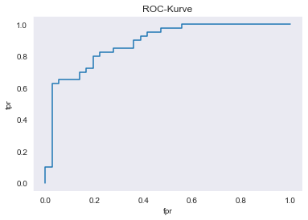

```python
from sklearn.metrics import roc_curve


y_test = [1 if x=="gesund" else 0 for x in y_test]
fpr, tpr, thresholds = roc_curve(y_test, pred)


plt.plot(fpr, tpr)
plt.title("ROC-Kurve")
plt.xlabel("fpr")
plt.ylabel("tpr")
plt.plot()
```

```python
from sklearn.metrics import roc_auc_score
pred_class = [1 if x=="gesund" else 0 for x in pred_class]
print("AUC = ", roc_auc_score(y_test, pred_class))
```

```
AUC =  0.7722222222222223
```